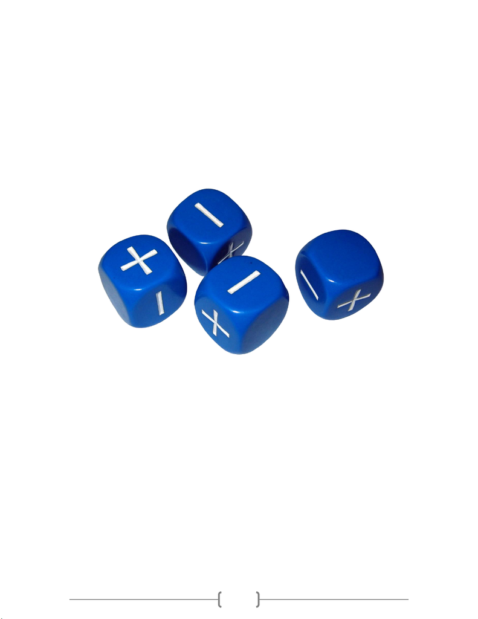

1

Ejercicios sugeridos para cálculo de probabilidades

[figure not shown]

2

1) ¿Cuántas indumentarias se pueden crear con 3 camisas, 5 pantalones y 2 pares de zapatos? Rta: ver al final del

documento.

2) Un salón de clase tiene 15 personas y se necesita elegir 3 personas para responder una encuesta. ¿Cuántos

subgrupos se podrían formar?

3) Un salón de clase tiene 15 personas y se necesita elegir 3 personas para un comité de representación, el primer

elegido será presidente, el segundo tesorero y el último será secretario. ¿Cuántos subgrupos se podrían formar?

4) El departamento de ventas de una empresa está formado por 5 mujeres y 4 hombres. Se debe formar un grupo

de cinco miembros para representar a la empresa en un seminario de ventas y la condición que existe es que el

grupo debe tener 3 mujeres. ¿Cuántos grupos se pueden formar para participar del seminario?

5) Cuatro libros distintos de matemáticas, tres diferentes de física y dos diferentes de química se colocan en un

estante. De cuántas formas distintas es posible ordenarlos si:

a) Los libros de cada tema deben estar todos juntos.

b) los libros de física deben estar juntos.

6) Se escriben a azar las cinco vocales. ¿Cuál es la probabilidad de que la “e” aparezca de primera y la “o” de

última.

7) Un estudiante que realiza un examen debe responder 7 de las 10 preguntas. El orden no importa. ¿De cuántas

formas puede responder el examen?

8) Una persona que sale de vacaciones desea llevarse 4 libros para leer: dispone de 4 novelas policiales y 6 cuentos

cortos. ¿De cuántas formas puede hacer la elección si quiere llevar al menos una novela? Note que la persona puede llevar 1 novela

y 3 cuentos ó 2 novelas y 2 cuentos …

9) Con las letras del alfabeto, ¿cuántas palabras se pueden formar de manera que cada palabra tenga cuatro

vocales y tres consonantes sin repetir consonante ni vocal? Nota: el enunciado está en español.

10) Un experimento consiste en lanzar tres monedas al aire. Sea A el evento de obtener al menos dos caras y B el

evento de obtener un sello. Calcular:

a) P(A)

b) P(B)

c) P(A∩B)

11) Mediante un diagnóstico una encuesta clasificó un grupo de voluntarios adultos dependiendo de si necesitaban

usar gafas para corregir su visión durante la lectura y si los empleaban para leer. Los resultados obtenidos son

presentados en la siguiente tabla de frecuencias.

Utiliza anteojos para leer

Si

No

Requiere

anteojos

Si

88

28

No

4

80

Suponga que se elige un adulto de este grupo, determine las probabilidades de los eventos que se definen en seguida.

[figure not shown]

3

a) El adulto requiere anteojos.

b) El adulto requiere anteojos pero no los utiliza

c) El adulto usa anteojos, ya sea que los requiera o no.

d) Si se eligen dos adultos al azar, ¿cuál es la probabilidad de que ambos requieran anteojos pero no los usen?

12) Las plataformas construidas para carga hidráulica que son ensambladas en unas instalaciones siempre pasan por

el departamento de control de calidad. Los registros indican que 8% de las plataformas tienen defectos sólo en

los elevadores, 5% posee defectos en los cojinetes de la polea y 2% tiene defectos en los elevadores y en los

cojinetes. Se elige uno de los montajes en forma aleatoria. Calcular la probabilidad de que una plataforma tenga:

a) Un defecto en los elevadores de la polea.

b) Defecto en los cojinetes o en los elevadores.

c) Exactamente una de las dos clases de defectos.

d) Ninguno de los dos defectos.

13) La urna A contiene 5 pelotas rojas y 3 azules, mientras que la urna B contiene 2 pelotas azules y 7 rojas. Se toma

una pelota de la urna A sin ver su color y se deposita en la urna B, luego se saca una pelota de la urna B. Calcular

la probabilidad de que:

a) Ambas pelotas elegidas de las urnas sean azules.

b) Ambas pelotas elegidas sean de diferente color.

14) Si dos eventos A y B tienen las siguiente probabilidades: P(A)=0.5, P(B)=0.3 y P(A∩B)=0.1, determine

analíticamente las siguientes probabilidades.

a) P(A│B)

b) P(B│A)

c) P(A│AᴜB)

d) P(A│A∩B)

e) P(A∩B│AᴜB)

Repita los literales anteriores organizando la información en un diagrama de Venn.

15) En una población de empleados se obtuvo la tabla que aparece a continuación y que contiene los porcentajes de

acuerdo con el género y el resultado de un examen. Se elegirá al azar un empleado de esta población. Suponga

que A es el evento de que el empleado aprueba el examen y H el evento de que el empleado sea un hombre.

¿Son independientes los eventos A y H? ¿Son independientes los eventos Ac y H?

Hombre (H)

Mujer (Hc)

Total

Aprovados (A)

24

36

60

Reprobados (Ac)

16

24

40

Total

40

60

100

16) Dos eventos A y B tiene probabilidades P(A)=0.2, P(B)=0.3 y P(AᴜB)=0.4. Determine analíticamente las siguientes

probabilidades:

a) P(A∩B)

b) P(Ac ᴜ Bc)

c) P(Ac ∩ Bc)

d) P(Ac │B)

4

e) P(Bc | (BᴜA))

Repita los literales anteriores usando un diagrama de Venn.

17) Un departamento de policía recarga sus extintores contra incendios con tres empresas diferentes A, B y C. De

datos históricos se sabe que el porcentaje de recargas defectuosas de A, B y C son 3%, 4% y 6% respectivamente.

El porcentaje de recargadas realizadas por el departamento de bomberos en cada una de las empresas ha sido

35%, 45% y 20% para A, B y C respectivamente.

a) Ayer se recibió un extintor recargado pero se desconoce la procedencia. ¿Cuál es la probabilidad de que esté

defectuoso?

b) Se recibe un extintor que NO está defectuoso. ¿Cuál es la probabilidad de que venga de la empresa C?

18) Hay dos métodos, A y B, para enseñar cierta destreza industrial. El porcentaje de fracaso del método A es 20% y

el de B 10%; sin embargo, como el método B es más caro se aplica sólo 30% del tiempo (el otro 70% se emplea

A). Una trabajadora recibió capacitación con uno de los métodos pero no aprendió la destreza. ¿Cuál es la

probabilidad de que se le haya enseñado con el método A?

19) Un recién graduado del bachillerato asiste al batallón del ejército para participar en un sencillo concurso del cual

puede salir favorecido para no tener que prestar el servicio militar. El concurso consiste en dos bolsas de tela

negra, en la primera hay cuatro bolas negras y dos blancas, en la segunda bolsa hay cinco bolas negras y tres

blancas. El estudiante debe sacar una bola de la primera bolsa y luego depositarla en la segunda bolsa, luego

sacar nuevamente una bola de la segunda bolsa. Si el estudiante saca dos bolas de diferente color se salva y no

presta el servicio. ¿Cuál es la probabilidad de que el estudiante se salve y no tenga que prestar el servicio

militar?

20) A un congreso asisten 80 congresistas de los países Inglaterra y Francia. De ellos 70 hablan inglés y 50 francés. Se

eligen dos congresistas al azar y se desea saber:

a. ¿Cuál la probabilidad de que se entiendan sin intérprete?

b. ¿Cuál es la probabilidad de que se entiendan sólo en francés?

c. ¿Cuál es la probabilidad de que se entiendan en un solo idioma?

d. ¿Cuál es la probabilidad de que se entiendan en los dos idiomas?

21) En una clase mixta hay 30 alumnas, 15 estudiantes que repiten curso, de los que 10 son alumnos, y hay 15

alumnos que no repiten curso. Se pide:

a. ¿Cuántos estudiantes hay en la clase?

b. Elegido al azar un estudiante ¿Cuál es la probabilidad de que sea alumno?

c. Elegido al azar un estudiante ¿Cuál es la probabilidad de que sea alumna y repita el curso?

d. Elegidos al azar dos estudiantes ¿Cuál es la probabilidad de que ninguno repita curso?

22) En un hospital especializado en enfermedades de tórax ingresan un 50 % de enfermos de bronquitis, un 30 % de

neumonía y un 20 % con gripe. La probabilidad de curación completa en cada una de dichas enfermedades es,

respectivamente, 0.7; 0.8 y 0.9. Un enfermo internado en el hospital ha sido dado de alta completamente

curado. Hallar la probabilidad de que el enfermo dado de alta hubiera ingresado con bronquitis.

5

23) La probabilidad de que un artículo provenga de una fábrica A1 es 0.7 y la probabilidad de que provenga de otra

A2 es el complemento. Se sabe que la fábrica A1 produce un 4 por mil de artículos defectuosos y la A2 un 8 por

mil.

a. Se observa un artículo y se ve que está defectuoso. ¿Cuál es la probabilidad de que provenga de la

fábrica A2?

b. Se pide un artículo a una de las dos fábricas, elegida al azar. ¿Cuál es la probabilidad de que esté

defectuoso?

c. Se piden 5 artículos a la fábrica A1 ¿Cuál es la probabilidad de que haya alguno defectuoso?

24) Se lanzan al aire dos dados de seis caras no cargados. Calcular la probabilidad de que la suma de las caras

superiores sea un número primo.

25) Sean A y B dos eventos tales que P(A)=0.6, P(B)=0.8 y P(A∩B)=0.5. Calcular P(A|Bc).

26) ¿Cuál es la probabilidad de sacar cuatro bolas negras de una urna que contiene 15 bolas blancas y 12 negras, sin

reintegrar la bola extraída? ¿Reintegrando la bola?

27) Una caja en un almacén contiene cuatro focos de 40W, cinco de 60W y seis de 75W. Suponga que se eligen al

azar tres focos. Calcular la probabilidad de que exactamente dos de los focos seleccionados sean de 75W.

28) En la universidad se hizo una encuesta a cincuenta estudiantes para indagar por el número de idiomas

diferentes al español que dominaban. De la encuesta se encontró que quince hombres manifestaron dominar

sólo un idioma, veintiocho encuestados saben dos idiomas y el número total de mujeres que participaron en la

encuesta fue de treinta y dos. Si se elige un encuestado al azar de los que hablan un solo idioma, calcular la

probabilidad de que sea mujer.

29) De los viajeros que llegan a un pequeño aeropuerto, 60% vuelan en líneas aéreas importantes, 30% en aviones

de propiedad privada y el resto en aviones comerciales que no pertenecen a una línea aérea importante. De

quienes viajan en líneas aéreas importantes, la mitad viaja por negocios, en tanto que 60% de quienes llegan en

aviones privados y 90% de quienes llegan en otros aviones comerciales viajan por negocios. Se selecciona al azar

una persona que llega a este aeropuerto, la probabilidad aproximada de que la persona viaje por negocios es:

30) Basándose en el enunciado anterior, calcular la probabilidad de que la persona llegue en un avión privado, dado

que la persona viaja por negocios.

31) Tres nombres se van a seleccionar de una lista de siete para una encuesta de opinión pública. Encuentre la

probabilidad de que el primer nombre de la lista sea seleccionado para la encuesta.

32) Un sistema detector de humo utiliza dos dispositivos, A y B. Si hay humo, la probabilidad que sea detectado por

el dispositivo A es 0.95; por el dispositivo B, 0.90; y por ambos dispositivos, 0.88. Si hay humo, encuentre la

probabilidad de que el humo no sea detectado por ninguno de los dispositivos.

[figure not shown]

6

33) Si A y B son eventos independientes con P(A)=0.5 y P(B)=0.2, calcular P(Ac∩Bc).

34) Se lanza un dado, si sale en la cara superior un número par (2, 4 o 6 ) se lanza una moneda una vez, si en el dado

aparece un número impar se lanza la moneda dos veces. ¿Cuál es la probabilidad de obtener al menos una cara?

Hacer los ejemplos y ejercicios del texto guía:

Respuestas ofrecidas por los estudiantes de semestres anteriores, si alguna no coincide por favor repórtelo para hacer la

corrección.

1. 30

2. 455

3. 2730

4. 60

5. 1728; 30240

6. 0.05

7. 120

8. 195

9. 38808000

10. ½; 3/8, 3/8

11. 0.58; 0.14; 0.46; 0.018994974

12. 0.10; 0.13; 0.11; 0.87

13. 9/80; 31/80

14. 1/3; 1/5; 5/7; 1; 1/7

15. Si; si

7

16. 0.1; 0.9; 0.6; 2/3; 1/4

17. 0.0405; 0.1959

18. 0.8235

19. 11/27

20. 143/158; 89/632; 52/79; 39/158

21. 55; 5/11; 1/11; 52/99

22. 0.455

23. 6/13; 13/2500; 0.019840

24. 15/36

25. ½

26. 0.028; 0.0390

27. 27/91 de Abraham y Samuel

28. 7/22

29. 0.57

30. 0.316

31. 3/7

32. 0.03

33. 0.4

34. 0.625